# Auswertung TC Daten

### 2.4.5 LFQ_D2_.png

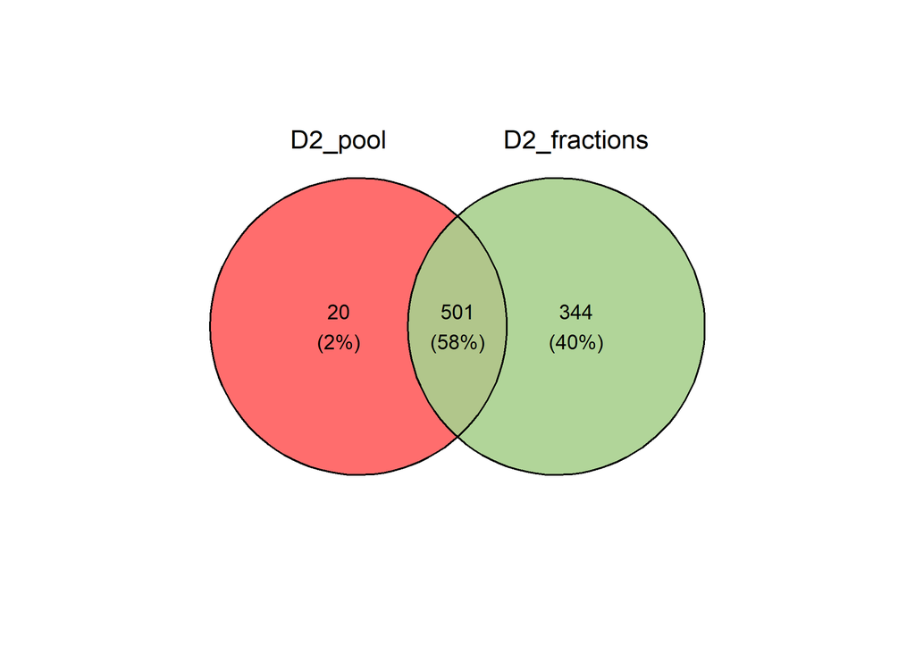

### 2.4.6 LFQ_MBR_D2_.png

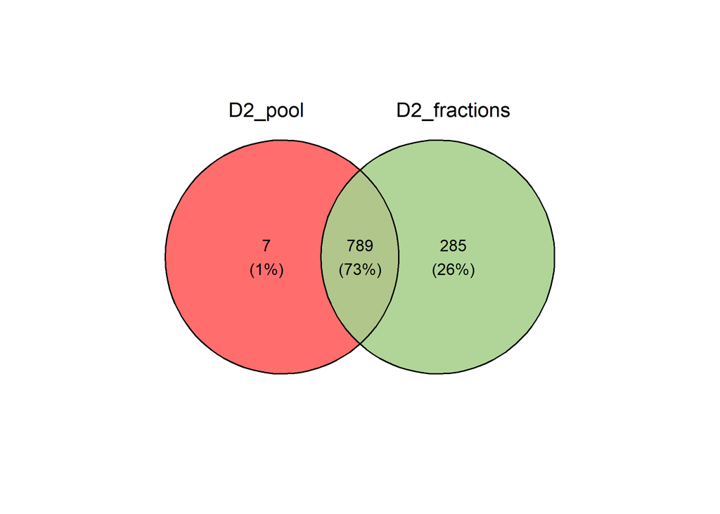

# 3 Besprechen/todo

- nehmen wir LFQ oder die identifizierten Proteine?
- nehmen wir razor oder unique? ich würde fast razor nehmen, weil ja ohnehin zu der proteingruppe zugeordnet wird die am wahrscheinlichsten ist
- wie poolen wir? zB B1_1, B1_2, B2_1, B2_2…
  - wenn ich dort alle Proteine zähle führt es ev. zu einem Überbefund?
  - wäre es nicht besser B1_1 und B1_2 -> nur wenn Protein in beiden vorkommt ist es auch da? weil ja technische replikate also 2x gemessen oder?
  - wenn 2 biologische replikate; also 2x extrahiert würde ich es so machen, dass ich auch sagen es ist da wenn es nur in einem Extrakt vorkommt | also zB B1_1 TRUE - B1_2 FALSE
- was gehört überhaupt gepooled und verglichen? können wir uns das bitte noch anschauen?
- was gehört bei D2 gepooled und verglichen?
- man könnte ja Razor nehmen und im paper bezug nehmen, dass ergebnisse ähnlich wie unique
- zusätzlich noch anschauen mit LFQ? wieviele proteine von den identifzierten sind überhaupt quantifizierbar? das könnte man auch ins paper geben, dass wenn man lfq nimmt man mit ca. 20-25%(also je nachdem was dann rauskommt) rechnen muss? weil ja später dann bei differential expression analysis ja auch quantifizierte proteine verwendet werden; also meistens halt

# 4 Compare D1 and D2 B1-B9 resp B1-B10

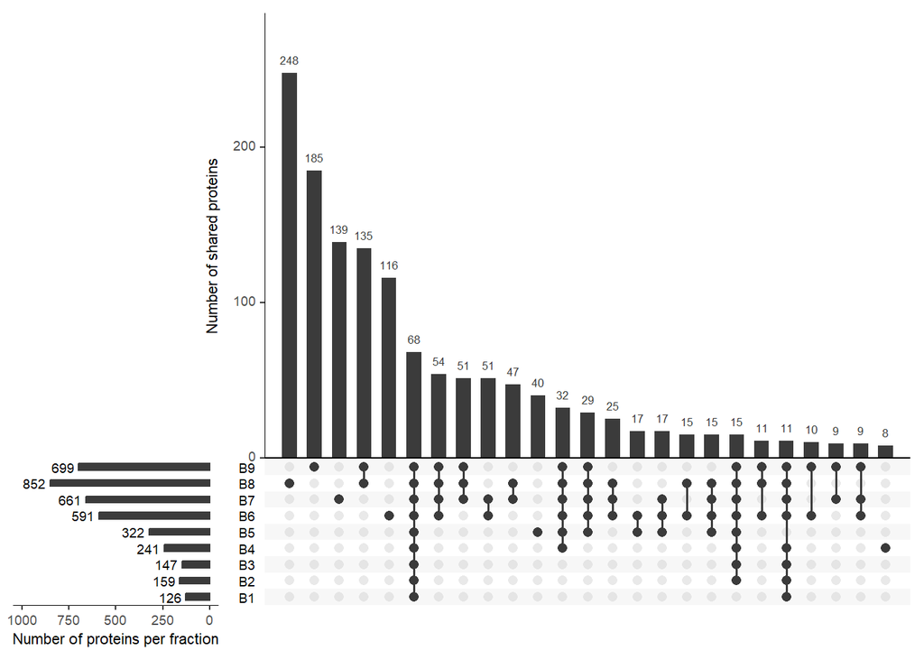

```r
library(dplyr)
library(UpSetR)
#D1
data <- readRDS(file = "results_v002/results_run1_mqpar_extracts_2gether_E4_D1_B_LFQ_combined_txt_proteinGroups.txt_Unique.RDS")
data <- data[[1]]
data_sub <- dplyr::select(data, contains("Pool_G"))
B_D1 <- data_sub*1
B_D1 <- sapply(seq(1,17,by=2),function(i) rowSums(B_D1[,i:(i+1)]))
B_D1[B_D1==0] <- NA

### analysis B
proteins <- as.data.frame(which(!is.na(B_D1), arr.ind=TRUE))

B1 <- proteins %>% dplyr::filter(col == 1)
B2 <- proteins %>% dplyr::filter(col == 2)
B3 <- proteins %>% dplyr::filter(col == 3)
B4 <- proteins %>% dplyr::filter(col == 4)
B5 <- proteins %>% dplyr::filter(col == 5)
B6 <- proteins %>% dplyr::filter(col == 6)
B7 <- proteins %>% dplyr::filter(col == 7)
B8 <- proteins %>% dplyr::filter(col == 8)
B9 <- proteins %>% dplyr::filter(col == 9)
# combine to list
lst <- list(B1 = as.double(B1[,1]),
            B2 = as.double(B2[,1]),
            B3 = as.double(B3[,1]),
            B4 = as.double(B4[,1]),
            B5 = as.double(B5[,1]),
            B6 = as.double(B6[,1]),
            B7 = as.double(B7[,1]),
            B8 = as.double(B8[,1]),
            B9 = as.double(B9[,1]))

upset(fromList(lst),
      order.by = "freq",
      nsets = 9,
      nintersects = 25,
      sets = c("B1","B2","B3","B4","B5","B6","B7","B8","B9"),
      keep.order = TRUE,
      mainbar.y.label = "Number of shared proteins",
      sets.x.label = "Number of proteins per fraction",
      set_size.show = TRUE,
      set_size.angles = 0,
      set_size.scale_max = 1000)
```

```r
#D2
data <- readRDS(file = "results_v002/results_run1_mqpar_extracts_2gether_D2_LFQ_combined_txt_proteinGroups.txt_Unique.RDS")
#data <- readRDS(file = "results_v002/results_run1_mqpar_extracts_2gether_D2_MBR_LFQ_combined_txt_proteinGroups.txt_Unique.RDS")
data <- data[[1]]
#for D2
data_sub <- dplyr::select(data, contains("Pool_20"))
B_D2 <- data_sub*1
B_D2 <- sapply(seq(1,19,by=2),function(i) rowSums(B_D2[,i:(i+1)]))
B_D2[B_D2==0] <- NA

### analysis B
proteins <- as.data.frame(which(!is.na(B_D2), arr.ind=TRUE))

B1 <- proteins %>% dplyr::filter(col == 1)
B10 <- proteins %>% dplyr::filter(col == 2)
B2 <- proteins %>% dplyr::filter(col == 3)
B3 <- proteins %>% dplyr::filter(col == 4)
B4 <- proteins %>% dplyr::filter(col == 5)
B5 <- proteins %>% dplyr::filter(col == 6)
B6 <- proteins %>% dplyr::filter(col == 7)
B7 <- proteins %>% dplyr::filter(col == 8)
B8 <- proteins %>% dplyr::filter(col == 9)
B9 <- proteins %>% dplyr::filter(col == 10)
# combine to list
lst <- list(B1 = as.double(B1[,1]),
            B2 = as.double(B2[,1]),
            B3 = as.double(B3[,1]),
            B4 = as.double(B4[,1]),
            B5 = as.double(B5[,1]),
            B6 = as.double(B6[,1]),
            B7 = as.double(B7[,1]),
            B8 = as.double(B8[,1]),
            B9 = as.double(B9[,1]),
            B10 = as.double(B10[,1]))

upset(fromList(lst),
      order.by = "freq",
      nsets = 9,
      nintersects = 25,
      sets = c("B1","B2","B3","B4","B5","B6","B7","B8","B9","B10"),
      keep.order = TRUE,
      mainbar.y.label = "Number of shared proteins",
      sets.x.label = "Number of proteins per fraction",
      set_size.show = TRUE,
      set_size.angles = 0,
      set_size.scale_max = 1000
)
```

[output not shown]

[figure not shown]

# 5 Complex UpsetR

- https://krassowski.github.io/complex-upset/articles/Examples_R.html